# Exercise #4: What is the economically “optimal” height of flood protection structures?: The Van Dantzig (1956) example

Patrick Applegate, patrick.applegate@psu.edu, Alexander Bakker, bakker@psu.edu, and Klaus Keller, klaus@psu.edu

2 December 2015

# Learning Goals

After completing this exercise, you should be able to

- describe the Van Dantzig (1956) approach to estimating the optimal height of flood protection structures (dikes)
- explain how discounting works and describe the effects of discounting rates on the results of cost-benefit analyses
- perform a simple Monte Carlo analysis based on Van Dantzig (1956)

# Introduction

Suppose that we are aware of a potential future danger. We don’t know the magnitude of this danger in advance, but we do know the risks it poses. That is, we know the probabilities and economic damages associated with different levels of danger. We also know the costs of putting protection in place. These protective measures are imperfect, and we may want to avoid spending more money on protection than is necessary. How do we decide how much protection to institute?

Van Dantzig (1956) considered this problem in the context of avoiding damaging floods from storm surges in the Netherlands. The Netherlands is a densely-populated and low-lying country in Europe. Storm surges occur when low-pressure regions associated with large storms cause local sea level to rise temporarily. These storm surges can be several meters high. A particularly large and damaging flood occurred in the Netherlands in 1953.

After the flood of 1953, a team of engineers and mathematicians set to work to design a set of dikes (levees) to protect the Netherlands from similar future events (Van Dantzig, 1956). The dikes could not be made tall enough to close out all potential future floods. The floods that had already happened suggested that even bigger ones could occur. As dikes are built higher, they also become wider and take up increasing amounts of valuable real estate. Thus, the cost of building very tall dikes becomes unreasonably large.

Traditional risk analyses, like the one carried out by Van Dantzig (1956), require some criterion for evaluating possible solutions. Van Dantzig (1956) suggested that one way of identifying an economically-optimal dike height is to evaluate the sum of the cost of dike construction and the expected damages due to future floods, for various potential dike heights. The damages are weighted (discounted) according to how far in the future they occur. The dike height that gives the lowest sum of construction costs and discounted flood damages is the economically “optimal” solution, in the Van Dantzig (1956) framework.

The minimum-total-cost criterion makes a number of assumptions, some of which we will discuss below. Despite these limitations, Van Dantzig (1956) presents a valuable example of traditional risk analysis as applied to flood protection, one that still provides a foundation for modern studies (see, for example, Lempert et al., 2012). This exercise follows sections 1-4 of Van Dantzig (1956), which present a simplified version of his full analysis. The appendix (see below) mentions some additional considerations that may lead to different answers.

## An important note

Carrying out this exercise will not prepare you to design flood protection structures. The presentation of the material in this exercise has been simplified for pedagogical reasons, and this material should only be applied to “real” problems after additional training. The authors and editors of this e-textbook specifically disclaim any liability for damages associated with the use of the material presented in this exercise.

## Dike construction costs

Van Dantzig (1956) argued that the cost of building a dike $I$ is a linear function of height $H$,

$I(H) = I_0+ kH$,

for small values of $H$. Strictly speaking, Van Dantzig (1956) analyzed the case in which dikes with an initial height $H_0$ are increased to a final height $H$, with the height increase $X = H- H_0$. Here, we assume that there are no existing protective structures, so that $H_0 = 0$ and $H = X$.

## Expected damages and the role of discounting

The question is then, how much damage should we expect from floods if we build the dikes to a particular height? Van Dantzig (1956) approached this question by

1. calculating the expected damage in a single year and
2. integrating these damages over all future times,
3. while assigning a reduced importance to floods that happen far in the future.

The **expected damage in a single year** is the losses due to a single flood, multiplied by the chances of a flood in a given year. Van Dantzig (1956) assumed that, in the case of a flood, the value $V$ of all goods (buildings, livestock, and other property) within the area protected by a dike would be lost. This assumption makes sense because, in the Netherlands, the areas protected by individual dikes (polders) fill with water like a bathtub if the dikes are overtopped or fail. Van Dantzig (1956; see also Wemelsfelder, 1939) noted that the annual maximum sea level values from the central Netherlands followed an exponential distribution,

$P(H) = p_0 e^{-\alpha H}$

Recall from Exercise #3 that an exponential distribution assigns the largest probabilities to small values, but has a long “tail” that can extend to large positive values. Multiplying the damage from one flood by the probability of flooding in one year gives

$V P(H) = V p_0 e^{-\alpha H}$

If we were to integrate these expected damages from flooding in a single year over all future times, we would arrive at an infintely large total future damages value, which would imply an unreasonably tall optimal dike height. However, the use of *discounting* in the Van Dantzig (1956) framework causes the integrated future flood damages to tend to a single, finite value.

Discounting **assigns a reduced weight to floods that happen far in the future**, and it is a common feature of cost-benefit analyses. In the context of flood protection, discounting is reasonable because spending money on flood protection now helps us avoid future flood damages. These avoided damages represent benefits, but we value future benefits less than the money we might spend on flood protection now. We define a *discount factor* $F_\textrm{d}$ that assigns a weight to future potential floods depending on how many years $t$ have gone by when they happen,

$F_\textrm{d} = (1+ \delta)^{-t}$

Putting the last two equations together, Van Dantzig (1956) arrived at an expression for the total future losses $L$ as a function of dike height $H$. The summation ($\Sigma$) in this expression **integrates flood damages over all future times**.

$L(H) = V P(H) \sum\limits_{t = 0}^{\infty} F_d$

Substituting for $P(H)$ and $F_\textrm{d}$ and simplifying, Van Dantzig (1956) obtained

$L(H) \approx (V p_0 e^{-\alpha H})/\delta$

How could Van Dantzig (1956) perform this simplification? Performing the summation $\sum\limits_{t = 0}^{\infty} (1+ \delta)^{-t}$, we see that it tends to $(1+ \delta)/\delta$. For small values of $\delta$, this factor is close to $1/\delta$. The code block below generates a figure (Fig. 1) that demonstrates this point.

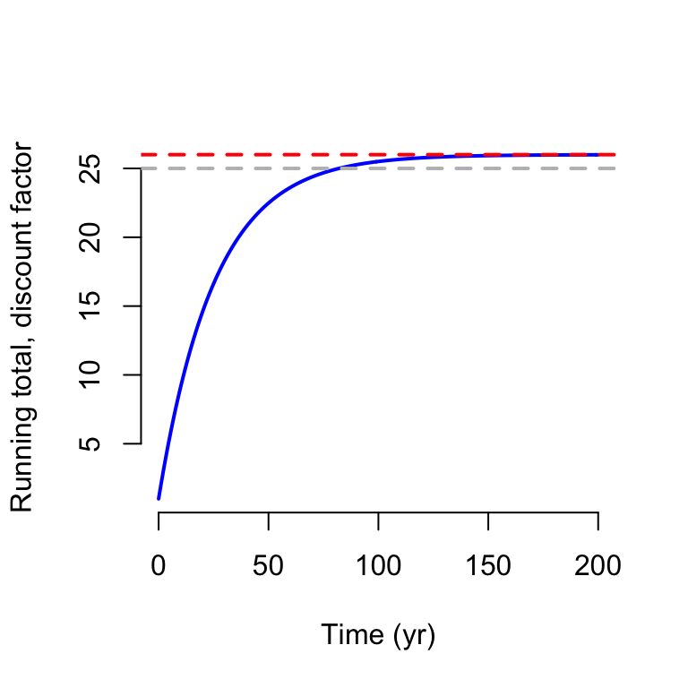

```r
# Demonstration that the cumulative sum of the discount factor tends to
# (1+ delta)/ delta as t becomes large, and that this value is close to
# 1/ delta for small values of delta.
delta <- 0.04             # discounting rate
t <- seq(0, 200, by = 1)  # vector of time values (years)
F.d <- (1+ delta)^ -t     # discount factor as a function of time
plot(t, cumsum(F.d), type = 'l', bty = 'n', lwd = 2, xlab = 'Time (yr)',
     ylab = 'Running total, discount factor', col = 'blue')
abline(h = (1+ delta)/ delta, lty = 2, lwd = 2, col = 'red')
abline(h = 1/ delta, lty = 2, lwd = 2, col = 'gray')
```

## Finding the optimal dike height

Recall that Van Dantzig (1956) suggested that the height of the dikes should be increased until the sum of their construction cost and the damages expected from future floods reaches a minimum. We now have an equation that describes the cost of building dikes as a function of their height, $I(H) = I_0+ kH$, and another equation that describes the expected future damages due to floods, also as a function of dike height, $L(H) \approx (V p_0 e^{-\alpha H})/\delta$.

The following code block plots $I(H)$, $L(H)$, and their sum $I(H)+ L(H)$, and finds the minimum on the total curve. This point corresponds to the optimal dike height, in the case where this analysis’ assumptions are satisfied.

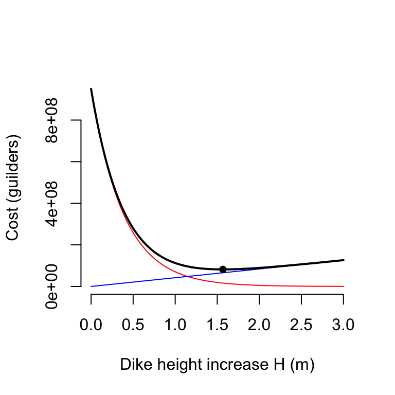

```r
# Constants from Van Dantzig (1956) -- read the whole paper carefully to see
# where these values come from
p_0 = 0.0038    # unitless; probability of flooding in a given year if the dikes
                # aren't built
alpha = 2.6     # unitless; constant associated with flooding probabilities
V = 10^ 10      # guilders; value of goods threatened by flooding
delta = 0.04    # unitless; discount rate
I_0 = 0         # guilders; initial cost of building dikes
k = 42* 10^ 6   # guilders/m; cost of raising the dikes by 1 m

# Make a vector of possible dike height increases in meters.
H = seq(0, 3, by = 0.001)

# Calculate the expected losses due to floods L, the cost of increasing the
# dikes I, and the total of L and I, all as a function of H.
L = p_0* exp(-alpha* H)* V/ (delta)
I = I_0+ k* H
Total = L+ I

# Make a plot.  The lowest point on the Total curve
# is the best value for H.
plot(H, L, type = 'l', col = 'red', xlab = 'Dike height increase H (m)',
     ylab = 'Cost (guilders)', bty = 'n')
lines(H, I, col = 'blue')
lines(H, Total, col = 'black', lwd = 2)

# Add a point indicating the minimum.
min_Total = Total[rank(Total) == 1]
min_H = H[rank(Total) == 1]
points(min_H, min_Total, pch = 16)
```

## Monte Carlo simulation

The method proposed by Van Dantzig (1956) for estimating optimal dike heights includes a number of parameters whose values have to be estimated (see the list in the code block above). Suppose that the probability distribution of floods of different heights is well-known and the initial cost of building higher dikes is 0 (that is, `p_0`, `alpha`, and `I_0` are fixed). In that case, we still have three uncertain parameters, the value of goods protected by flooding `V`, the discount rate `delta`, and the cost of raising the dikes by 1 m `k`. How can we assess the uncertainty in the optimal dike height, given that these parameters aren’t known perfectly?

Monte Carlo simulation (e.g. Bevington and Robinson, 2002, their ch. 5) provides a method for estimating the uncertainty in a calculated output, given probability distributions of the inputs. To carry out Monte Carlo simulation, we

1. generate groups of input parameter values randomly (see Exercise #3),
2. feed each group of input parameters into the model and record the outputs, and
3. plot the distributions of the output.

As a simple example, suppose we want to estimate the area of a circle, but we only know that its radius is somewhere between 0 and 1 units. We assume that the distribution of radius values is uniform, make a vector of possible values, feed them into the equation for a circle, and histogram the results. As shown in Figure 3, the distribution of outputs looks very different from the distribution of inputs.

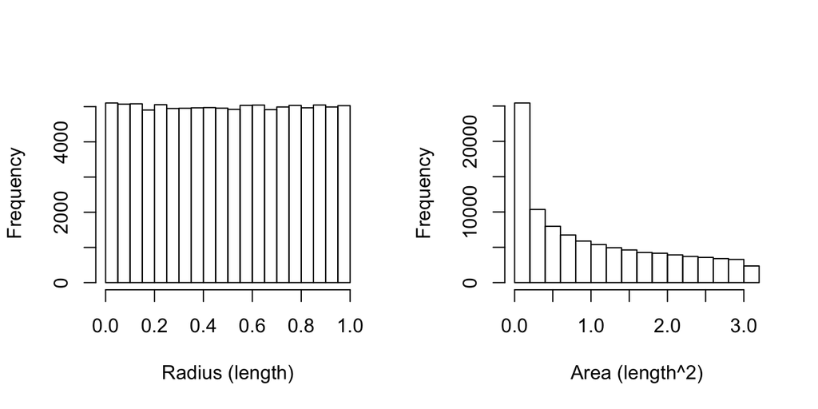

```r
# Creates randomly-sampled values of a circle's radius, calculates the area of
# the circle from each of the radius values, and makes histograms of the
# radius and area values.
n.trials <- 10^5    # number of Monte Carlo trials to attempt
radius <- runif(n.trials, min = 0, max = 1)
area <- pi* radius^2
par(mfrow = c(1, 2))
hist(radius, main = '', xlab = 'Radius (length)')
hist(area, main = '', xlab = 'Area (length^2)')
```

In the code block above, note that both `radius` and `area` are vectors that each contain `n.trials` values.

How could we apply Monte Carlo simulation to the Van Dantzig (1956) analysis? In addition to the equations above, Van Dantzig (1956) presents a separate equation that gives the optimal dike height directly,

$H_{best} = \alpha ^{-1} \ln [(V p_0 \alpha)/(\delta k)]$

We can imagine generating vectors of the uncertain parameters, feeding them into the equation above, and making a histogram of the optimal dike height values for all the parameter groups. That histogram would give us some idea of how sure we can be about the optimal dike height.

# Tutorial

Open the R script `lab4_sample.R` and inspect the contents. This script performs a simple Monte Carlo analysis with Van Dantzig (1956)’s equation for the optimal dike height, varying the parameter $\delta$ between 0.95 and 1.05 of its base value.

The first part of the code is straightforward; it provides an explanation of what the script does, clears the workspace, and sets the values for different parameters in the equation above.

```r
# lab4_sample.R
# Patrick Applegate, patrick.applegate@psu.edu
#
# Performs a simple Monte Carlo analysis with the optimal dike height
# equation from Van Dantzig (1956).

# Clear any existing variables and plots.
rm(list = ls())
graphics.off()

# Constants from Van Dantzig (1956)
p_0 = 0.0038      # unitless; probability of flooding in 1 yr if the dikes
                  # aren't built
alpha = 2.6       # unitless; constant associated with flooding probabilities
V = 10^ 10        # guilders; value of goods threatened by flooding
delta = 0.04      # unitless; discount rate
I_0 = 0           # guilders; initial cost of building dikes
k = 42* 10^ 6     # guilders/m; cost of raising the dikes by 1 m
```

The next group of commands determines how many Monte Carlo calculations to perform (`n.trials`), the range of each parameter to search over (`range`), and how wide a range of values will be reported by the script when it’s run (`probs`). `probs <- c(0.025, 0.5, 0.975)` tells the script to report the 95% range of the results, plus the median.

```r
# Set some other values.
n.trials <- 10^5  # number of Monte Carlo trials to do
range <- 0.1      # fractional range of each parameter to test
probs <- c(0.025, 0.5, 0.975)
                  # which quantiles to report
```

The random sampling is handled in the next block of code. Note the use of the `set.seed()` command to ensure that the script will give reproducible results.

```r
# Set the seed for random sampling.
set.seed(1)

# Perform the random sampling.
facs <- c((1- 0.5* range), (1+ 0.5* range))
delta.vals <- runif(n.trials, min = facs[1]* delta,
               max = facs[2]* delta)
```

Finally, the code calculates the optimal dike height for each value of `delta.vals` and makes a histogram of the `best.heights`, with a vertical red line to indicate the height obtained using the best estimate of each uncertain parameter. The quantiles of the values in `best.heights` are also written to the screen.

```r
# Calculate the optimal dike heights.
best.heights <- alpha^-1* log((V* p_0* alpha)/ (delta.vals* k))

# Make a histogram and print the quantiles to the screen.
hist(best.heights, main = '', xlab = 'Optimal dike heights (m)')
abline(v = alpha^-1* log((V* p_0* alpha)/ (delta* k)), lwd = 2, col = 'red')
print(round(quantile(best.heights, probs = probs), 3))
```

# Exercise

*Part 1.* Make a plot of the discount factor $F_\textrm{d}$ for `delta = seq(0, 0.1, by = 0.2)` over the time interval 0-200 yr. (Make sure you are plotting the discount factor, not its cumulative sum as shown in Fig. 1.)  
*Part 2.* Execute `lab4_sample.R` and take note of the quantiles that the script produces. Save a copy of the histogram produced by the script.  
*Part 3.* Make a copy of `lab4_sample.R` by saving it with a different file name. Modify this copied file so that it incorporates randomly-selected `V` and `k` values into the Monte Carlo simulation. You’ll need to create vectors `V.vals` and `k.vals` and populate them with random values, using code similar to that for `delta.vals`, above. You’ll also need to change the line in which `best.heights` is calculated, to incorporate these values into calculation of the optimal dike heights. Execute this new script, take note of the quantiles, and save a copy of the histogram it produces.

# Questions

1. For each of the discount factors you investigated in Part 1, how much weight do losses at the end of 100 years have relative to losses now?
2. Compare the distribution of `best.heights` from Part 2 to the distribution of values in `delta.vals`. Do these distributions look like one another?
3. Now compare the histograms and quantiles from Parts 2 and 3 to one another. How does the distribution of `best.heights` change as more free parameters are added to the calculation?

# Appendix

After reading Van Dantzig (1956), address some or all of the following questions. These questions are intended for students with advanced backgrounds in the Earth sciences and R programming.

1. What dike height does Van Dantzig (1956) identify as a “reasonable estimate of a sufficiently safe height”? How does this value compare to that marked by the black dot in Figure 2? What are the reasons for this difference?
2. Make a list of the assumptions that Van Dantzig (1956) explicitly mentions in the paper. Can you think of any other assumptions that he does not discuss? How does each of these assumptions affect the answer? That is, if each of these assumptions were relaxed, would the optimal dike height be greater or smaller than the value identified by Van Dantzig (1956)?
3. Examine Morgan and Henrion (1990, their section 3.4.1). Which of the decision criteria from Morgan and Henrion (1990, their Table 3.2) did we apply in Figure 2? Which decision criterion does Van Dantzig (1956) use in determining his “reasonable estimate of a sufficiently safe height”? Are any of the other decision criteria from Morgan and Henrion (1990, their Section 3.4.1) potentially relevant for building flood protection structures?
4. Make a list of the parameters that go into the Van Dantzig (1956) analysis. How did Van Dantzig (1956) decide which value of each parameter to use? Do you agree with these parameter values? Why or why not? What determines whether a parameter combination is “appropriate” or “good” in the context of this problem?
5. The exercise above assumes that relative sea level is constant over time. However, as Van Dantzig (1956) points out, relative sea level is actually increasing over time due to sinking of the land (plus increases in global mean sea level, as discussed elsewhere in this e-textbook). How would such increases in relative sea level affect the simplified analysis presented above?
6. What does Van Dantzig (1956) mean by his reference to a “utility function”? How could a utility function be built into this analysis? How might the answer change if the analysis were redone in this way?
7. How could this analysis be applied to another place with a fundamentally different distribution of annual maximum flood heights?
8. Suppose that sea level is rising (as in question #5, above), but we can’t be sure about the trajectory of future sea level change. How could we design a strategy for incrementally raising the dikes based on observations of yearly sea level?
9. In the original Van Dantzig (1956) analysis, the probability distribution of annual-maximum flood levels is constant over time. What would happen if higher floods, relative to mean sea level, became more probable over time? How could this change be built into this type of analysis?
10. Identify one other potential weakness in the Van Dantzig (1956) analysis and describe a way in which the analysis could be changed or updated to address this problem. If you were to carry out this improved analysis, would the optimal dike height be greater or smaller?

# References

Bevington, P. R., and Robinson, D. K., 2002. Data Reduction and Error Analysis for the Physical Sciences. McGraw-Hill, 320 p.

Lempert, R., Sriver, R. L., and Keller, K., 2012. Characterizing uncertain sea level rise projections to support investment decisions. California Energy Commission White Paper CEC-500-2012-056.

Morgan, M. G., and Henrion, M., 1990. Uncertainty: A Guide to Dealing with Uncertainty in Quantitative Risk and Policy Analysis. Cambridge University Press, 332 p.

van Dantzig, D., 1956. Economic decision problems for flood prevention. Econometrica 24, 276-287.

Wemelsfelder, P. J., 1939. Wetmatigheden in het optreden van stormvloeden. De Ingenieur 54(9), 31-35.